# 2.1 Concordancing

Author

Affiliation

Vladimir Buskin

Catholic University of Eichstätt-Ingolstadt

Abstract

This unit introduces the concept of a corpus and concordancing with R using the `quanteda` package, demonstrating keyword-in-context searches, data export, and the analysis of dispersion and word frequencies for transparent corpus-linguistic research.

## Recommended reading

- In-depth introduction to concordancing with R:

> Schweinberger (2024)
- Natural Language Processing (NLP) with `quanteda`:

> Benoit et al. (2018)

> [Online reference](http://quanteda.io)
- On corpus-linguistic theory:

> Wulff and Baker (2020)

> Lange and Leuckert (2020)

> McEnery, Xiao, and Yukio (2006): Units A1–A2

## What is a corpus?

Before we start querying corpora, it is worth considering what a corpus actually is. Although there are many ways to define a corpus, McEnery et al. (2006: 5) note an increasing consensus that it is

> a collection of (1) *machine-readable* (2) *authentic* texts (including transcripts of spoken data) which is (3) *sampled* to be (4) *representative* of a particular language or language variety.

Each of these four criteria has practical consequences for our work:

- **Machine-readable**: Since corpora are stored electronically, we can search, sort and count their contents quickly, accurately and consistently – which is exactly what we will do with R in this unit.
- **Authentic**: Corpora contain naturally occurring language rather than invented examples. Our intuitions about language may be shaped by our own dialect or sociolect, and they cannot tell us how often something occurs. Corpora, in contrast, show us what speakers and writers actually produce and provide quantitative data. Nevertheless, the two approaches are best seen as complementary rather than mutually exclusive (McEnery, Xiao, and Yukio 2006: 6–7).
- **Sampled** and **representative**: Since it is impossible to analyse every utterance of a language, a corpus is always a **sample** of a much larger **population**. It is considered representative if the findings based on it can be generalised to the language variety it is supposed to represent. In Biber’s words, representativeness ‘refers to the extent to which a sample includes the full range of variability in a population’ (quoted in McEnery, Xiao, and Yukio 2006: 13). This mainly depends on the range of text categories included in the corpus (its **balance**) and on how the texts for each category are selected (**sampling**). The relationship between samples and populations will be discussed in more detail in 3.1 Data, variables, samples.

The *International Corpus of English* (ICE) illustrates these principles very well. All ICE components are compiled according to the same design: Each comprises about one million words, divided into 500 texts of approximately 2,000 words each, of which 300 are spoken and 200 are written. The texts are distributed across fixed text categories, such as face-to-face conversations (S1A) or academic writing (W2A), which you will encounter in the document names below. This common design is what makes the components comparable and, therefore, so valuable for research on World Englishes.

**How much data is enough?**

Text samples of 2,000 words are usually sufficient for studying frequent linguistic features, whereas rare features vary more in their distribution and require larger samples (McEnery, Xiao, and Yukio 2006: 20). With roughly one million words per variety, a single ICE component may therefore yield only a handful of examples of rare constructions. It is a good idea to check the frequencies of your variants early on!

**Corpus linguistics: theory or methodology?**

McEnery et al. (2006: 7–8) regard corpus linguistics as a **methodology** rather than an independent branch of linguistics: Unlike phonetics, syntax or semantics, it is not restricted to a particular aspect of language but can be applied to almost any area of linguistic research.

A related debate concerns the distinction between **corpus-based** and **corpus-driven** approaches. Corpus-based studies typically take existing theories and descriptions as their starting point and test or revise them in the light of corpus evidence. Corpus-driven linguists, by contrast, claim to approach corpora without preconceived categories. McEnery et al. (2006: 8–11) argue that this distinction is overstated in practice. The corpus studies in this reader are corpus-based in the sense that they test hypotheses derived from the research literature against corpus data.

## Preparation

**Script**

You can find the full R script associated with this unit [here](https://osf.io/duras).

**Working directory**

To ensure that R can correctly access your data, it is crucial to set the working directory appropriately (see also 1.6 Importing/Exporting). The simplest approach is to create an **R project** in a directory of your choice and open it (see the small blue symbol in the top-right corner of the RStudio interface). If this is not feasible, or if you prefer to work outside an R project, you can follow these steps:

1. Make sure your R script **and** the corpus (e.g., ‘ICE-GB’) are stored in the **same folder** on your computer.
2. In RStudio, go to the `Files` pane (usually in the bottom-right corner) and navigate to the location of your script. Alternatively, you can click on the three dots `...` and use the file browser instead.
3. Once you’re in the correct folder, click on the blue ⚙️ icon.
4. Select `Set As Working Directory`. This action will update your working directory to the folder where the file is located.

In addition, make sure you have installed `quanteda` and any other packages you’re planning to use. Load them at the beginning of your script:

```r
library(quanteda) # Package for Natural Language Processing in R
library(quanteda.textplots) # supplementary package
library(quanteda.textstats) # supplementary package
library(writexl) # exporting data in MS Excel format
library(tidyverse) # data manipulation (needed for the advanced section)
```

To load a corpus object into R, place it in your working directory and read it into your working environment with `readRDS()`.[^1]

<sup>1</sup> The `ICE_GB.RDS` file you’ve been provided with has been pre-processed and saved in this specific format for practical reasons. It contains the corpus as a `quanteda` **tokens** object, i.e., every text has already been split up into individual tokens (words, punctuation marks, etc.).

```r
# Load corpus from directory
ICE_GB <- readRDS("ICE_GB.RDS")
```

If you encounter any error messages at this stage, ensure you followed steps 1 and 2 in the callout box above.

## Concordancing

A core task in corpus-linguistic research involves finding occurrences of a single word or multi-word sequence in the corpus. Lange & Leuckert (2020: 55) explain that specialised software typically “provide[s] the surrounding context as well as the name of the file in which the word could be identified.” Inspecting the context is particularly important in comparative research, as it may be indicative of distinct usage patterns.

### Simple queries

To obtain such a **keyword in context (KWIC)** in R, we use the `kwic()` function. We supply the corpus as well as the keyword we’re interested in:

```r
query1 <- kwic(ICE_GB, pattern = "eat")
```

The output in `query1` contains **concordance lines** that list all occurrences of the keyword, including the document, context to the left, the keyword itself, and the context to the right. The final column reiterates our search expression.

```r
head(query1)
```

```
Keyword-in-context with 6 matches.
  [ICE_GB/S1A-006.txt, 785]           So I' d rather | eat |
 [ICE_GB/S1A-009.txt, 1198]              I must <, > | eat |
  [ICE_GB/S1A-010.txt, 958]         to <, > actually | eat |
  [ICE_GB/S1A-018.txt, 455] order one first and then | eat |
  [ICE_GB/S1A-018.txt, 498]  A > The bargain hunting | eat |
 [ICE_GB/S1A-023.txt, 1853]       B > Oh name please | eat |

 beforehand just to avoid uh
 them < ICE-GB:S1A-009#71:
 it for one' s
 it and then sort of
 < ICE-GB:S1A-018#29: 1
 something <,, >
```

For a full-screen display of the KWIC data frame, try `View()`:

```r
View(query1)
```

| docname | from | to | pre | keyword | post | pattern |
| --- | --- | --- | --- | --- | --- | --- |
| ICE_GB/S1A-006.txt | 785 | 785 | So I ' d rather | eat | beforehand just to avoid uh | eat |
| ICE_GB/S1A-009.txt | 1198 | 1198 | I must < , > | eat | them < ICE-GB:S1A-009 #71 : | eat |
| ICE_GB/S1A-010.txt | 958 | 958 | to < , > actually | eat | it for one ' s | eat |
| ICE_GB/S1A-018.txt | 455 | 455 | order one first and then | eat | it and then sort of | eat |
| ICE_GB/S1A-018.txt | 498 | 498 | A > The bargain hunting | eat | < ICE-GB:S1A-018 #29 : 1 | eat |
| ICE_GB/S1A-023.txt | 1853 | 1853 | B > Oh name please | eat | something < , , > | eat |

**What are all these symbols in the context columns?**

The ICE corpora contain **markup**, i.e., additional information enclosed in angle brackets `< >`. For example, `< ICE-GB:S1A-009 #71 : 1 : A >` marks the beginning of text unit no. 71 in file S1A-009, which is uttered by speaker A, and `< , >` indicates a short pause. When reading concordance lines, this information can be very useful, so we will leave it in for now. When counting words, however, it becomes a nuisance (see Advanced techniques below).

### Multi-word queries

If the search expression consists of more than one word, we need to mark it as a multi-word sequence by means of the `phrase()` function. For instance, if we were interested in the pattern *eat a*, we’d have to adjust the code as follows:

```r
query2 <- kwic(ICE_GB, pattern = phrase("eat a"))
```

```r
View(query2)
```

| docname | from | to | pre | keyword | post | pattern |
| --- | --- | --- | --- | --- | --- | --- |
| ICE_GB/S1A-059.txt | 2230 | 2231 | 1 : B > I | eat a | < , > very balanced | eat a |
| ICE_GB/W2B-014.txt | 1045 | 1046 | : 1 > We can't | eat a | lot of Welsh or Scottish | eat a |
| ICE_GB/W2B-022.txt | 589 | 590 | have few labour-saving devices , | eat a | diet low in protein , | eat a |

### Multiple simultaneous queries

A very powerful advantage of `quanteda` over traditional corpus software is that we can query a corpus for a multitude of keywords **at the same time**. Say we need our output to contain hits for *eat*, *drink* and *sleep*. Instead of a single keyword, we supply a character vector `words` containing the strings of interest.[^2]

<sup>2</sup> Naturally, you can choose any other variable name besides `words`.

```r
words <- c("eat", "drink", "sleep")

query3 <- kwic(ICE_GB, pattern = words)
```

```r
View(query3)
```

| docname | from | to | pre | keyword | post | pattern |
| --- | --- | --- | --- | --- | --- | --- |
| ICE_GB/S1A-006.txt | 785 | 785 | So I ' d rather | eat | beforehand just to avoid uh | eat |
| ICE_GB/S1A-009.txt | 869 | 869 | : A > Do you | drink | quite a lot of it | drink |
| ICE_GB/S1A-009.txt | 1198 | 1198 | I must < , > | eat | them < ICE-GB:S1A-009 #71 : | eat |
| ICE_GB/S1A-010.txt | 958 | 958 | to < , > actually | eat | it for one ' s | eat |
| ICE_GB/S1A-014.txt | 3262 | 3262 | you were advised not to | drink | water in Leningrad because they | drink |
| ICE_GB/S1A-016.txt | 3290 | 3290 | > I couldn't I couldn't | sleep | if I didn't read < | sleep |

### Window size

Some studies require more detailed examination of the preceding or following context of the keyword. We can easily adjust the `window` size to suit our needs:

```r
query4 <- kwic(ICE_GB, pattern = "eat", window = 20)
```

| docname | from | to | pre | keyword | post | pattern |
| --- | --- | --- | --- | --- | --- | --- |
| ICE_GB/S1A-006.txt | 785 | 785 | #49 : 1 : A > Yeah < ICE-GB:S1A-006 #50 : 1 : A > So I ' d rather | eat | beforehand just to avoid uh < , , > any problems there < ICE-GB:S1A-006 #51 : 1 : B > | eat |
| ICE_GB/S1A-009.txt | 1198 | 1198 | < , > in in the summer < ICE-GB:S1A-009 #70 : 1 : A > I must < , > | eat | them < ICE-GB:S1A-009 #71 : 1 : A > Yes < ICE-GB:S1A-009 #72 : 1 : B > You ought | eat |
| ICE_GB/S1A-010.txt | 958 | 958 | 1 : B > You know I mean it would seem to be squandering it to < , > actually | eat | it for one ' s own enjoyment < , , > < ICE-GB:S1A-010 #49 : 1 : A > Mm | eat |
| ICE_GB/S1A-018.txt | 455 | 455 | s so < ICE-GB:S1A-018 #27 : 1 : A > What you should do is order one first and then | eat | it and then sort of carry on from there < laughter > < , > by which time you wouldn't | eat |
| ICE_GB/S1A-018.txt | 498 | 498 | second anyway so < laugh > < , > < ICE-GB:S1A-018 #28 : 1 : A > The bargain hunting | eat | < ICE-GB:S1A-018 #29 : 1 : B > So all right what did I have < ICE-GB:S1A-018 #30 : 1 | eat |
| ICE_GB/S1A-023.txt | 1853 | 1853 | > I can't bear it < , , > < ICE-GB:S1A-023 #121 : 1 : B > Oh name please | eat | something < , , > < ICE-GB:S1A-023 #122 : 1 : A > Oh actually Dad asked me if < | eat |

### Saving your output

You can store your results in a spreadsheet file just as described in the unit on importing and exporting data.

- **Microsoft Excel** (.xlsx)

```r
write_xlsx(query1, "myresults1.xlsx")
```

- **CSV** (.csv)

```r
write.csv(query1, "myresults1.csv", row.names = FALSE)
```

As soon as you have annotated your data, you can load .xlsx files back into R with `read_xlsx()` from the `readxl` package and .csv files using the base R function `read.csv()`.

## Characterising the output

Recall our initial query of the verb *eat*, whose output we stored in `query1`:

| docname | from | to | pre | keyword | post | pattern |
| --- | --- | --- | --- | --- | --- | --- |
| ICE_GB/S1A-006.txt | 785 | 785 | So I ' d rather | eat | beforehand just to avoid uh | eat |
| ICE_GB/S1A-009.txt | 1198 | 1198 | I must < , > | eat | them < ICE-GB:S1A-009 #71 : | eat |
| ICE_GB/S1A-010.txt | 958 | 958 | to < , > actually | eat | it for one ' s | eat |
| ICE_GB/S1A-018.txt | 455 | 455 | order one first and then | eat | it and then sort of | eat |
| ICE_GB/S1A-018.txt | 498 | 498 | A > The bargain hunting | eat | < ICE-GB:S1A-018 #29 : 1 | eat |
| ICE_GB/S1A-023.txt | 1853 | 1853 | B > Oh name please | eat | something < , , > | eat |

First, we may be interested in obtaining some general information on our results:

- How many **tokens** (= individual hits) does the query return?

The `nrow()` function counts the number of rows in a data frame — these always correspond to the number of **observations** in our sample (here: 53).

```r
nrow(query1)
```

```
[1] 53
```

- How many **types** (= distinct hits) does the query return?

By default, `kwic()` ignores capitalisation. This is why `query1` contains 52 instances of *eat* in lower case and 1 in upper case, which together add up to our 53 observations.

```r
table(query1$keyword)
```

```
eat Eat
 52   1
```

Since *eat* and *Eat* are merely spelling variants of the same word form, it usually makes sense to convert all keywords to lower case before counting them:

```r
table(tolower(query1$keyword))
```

```
eat
 53
```

- How is the keyword distributed across corpus files?

This question relates to the notion of **dispersion**: Is a keyword spread relatively evenly across corpus files or does it only occur in specific ones? The `quanteda.textplots` package provides a very handy plotting function:

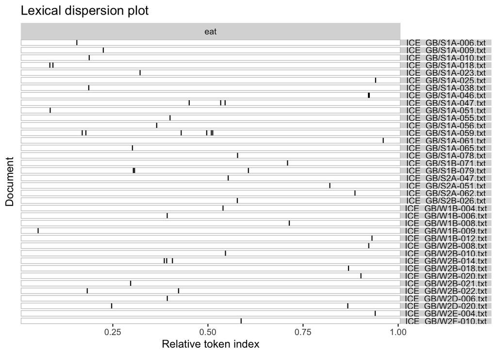

```r
textplot_xray(query1)
```

It seems that *eat* occurs at least once in most text categories (both spoken and written), but it is much more common in face-to-face conversations (S1A). This is not surprising: It is certainly more common to discuss food in a casual chat with friends than in an academic essay (unless, of course, its main subject matter is food). Dispersion measures can thus be viewed as indicators of **contextual preferences** associated with lexemes or more abstract grammatical patterns.

## Advanced techniques

### Word frequencies

We can generate a **document-feature matrix** (‘dfm’) by counting every single token in every ICE text.

```r
dfmat_raw <- dfm(ICE_GB)

print(dfmat_raw, max_ndoc = 10, max_nfeat = 20)
```

```
Document-feature matrix of: 500 documents, 41,413 features (97.97% sparse) and 0 docvars.
                    features
docs                   < ice-gb:s1a-001 #1   :   1   a   > ok adam uhm   , what
  ICE_GB/S1A-001.txt 338            127  1 254 127  85 338  5    2  70 234   23
  ICE_GB/S1A-002.txt 347              0  1 330 116  72 347  0    3  96 197   13
  ICE_GB/S1A-003.txt 430              0  1 336 168  96 430  1    3  78 271   14
  ICE_GB/S1A-004.txt 430              0  1 292 146 123 430  5    2  70 344   20
  ICE_GB/S1A-005.txt 365              0  1 516 258 165 365  2    0  31 120   13
  ICE_GB/S1A-006.txt 397              0  1 658 329 206 397  0    0  12  65   14
  ICE_GB/S1A-007.txt 387              0  1 624 312 136 387  0    0   8  82   16
  ICE_GB/S1A-008.txt 344              0  1 590 295 210 344  2    0  19  38   15
  ICE_GB/S1A-009.txt 503              0  1 684 342 225 503  0    0  20 171    9
  ICE_GB/S1A-010.txt 474              0  1 584 292 168 474  2    0  33 230   17
                    features
docs                 did you see as missing from other activities
  ICE_GB/S1A-001.txt   4  21   6 15       2   16    13          4
  ICE_GB/S1A-002.txt   2  75   4  5       0    4     8          0
  ICE_GB/S1A-003.txt   3  69   4 13       0    3     4          2
  ICE_GB/S1A-004.txt  11  25   1 12       0    4    10          0
  ICE_GB/S1A-005.txt   5  43   6  7       0    7     2          0
  ICE_GB/S1A-006.txt   4  51   7  7       0    1     0          0
  ICE_GB/S1A-007.txt   2  59   8  8       0   10     3          0
  ICE_GB/S1A-008.txt  13  60   3 13       0    3     0          0
  ICE_GB/S1A-009.txt  12  41   4 10       0    3     2          0
  ICE_GB/S1A-010.txt   4  81   0 10       0    1     3          0
[ reached max_ndoc ... 490 more documents, reached max_nfeat ... 41,393 more features ]
```

If text categories are irrelevant, we can obtain the global rank-frequency distribution of all tokens as follows:

```r
textstat_frequency(dfmat_raw, n = 20)
```

```
   feature frequency rank docfreq group
1        :    150119    1     500   all
2        >    122667    2     500   all
3        <    122664    3     500   all
4        1     73559    4     500   all
5      the     59586    5     500   all
6        a     55805    6     500   all
7        ,     54219    7     500   all
8       of     29961    8     500   all
9      and     27640    9     500   all
10      to     27627   10     500   all
11       '     21433   11     490   all
12       .     20504   12     201   all
13      in     19404   13     500   all
14       i     19149   14     418   all
15       b     18030   15     273   all
16    that     17204   16     500   all
17      it     16810   17     500   all
18     you     13805   18     385   all
19       s     13325   19     490   all
20      is     12833   20     498   all
```

Something is clearly off here: The most frequent ‘words’ in ICE-GB are apparently `:`, `>`, `<` and `1`. These tokens stem from the corpus markup, in particular from the text unit headers of the form `< ICE-GB:S1A-001 #1 : 1 : A >`, which occur at the beginning of every single text unit. Note also that `dfm()` converts all tokens to lower case by default. The speaker labels *A* and *B* are therefore counted together with the article *a* and the letter *b*: More than half of the 55,805 instances of *a* are, in fact, speaker labels!

### Removing markup

Since all markup in ICE is enclosed in angle brackets, we can remove it with a **regular expression**, i.e., a search pattern that describes the sequences of characters we want to find. The pattern `< [^<>]* >` below can be read as ‘an opening bracket `<`, followed by any number of characters that are not brackets (`[^<>]*`), followed by a closing bracket `>`’. Don’t worry if this looks cryptic – regular expressions are the topic of the next unit.

In addition, ICE encodes special characters by means of short codes enclosed by `&` and `;`, such as `&lsquo;` for the quotation mark ‘ or `&pound-sign;` for £. We remove these as well.[^3]

<sup>3</sup> This also splits up the few words that contain accented letters (e.g., *blasé* for *blasé*), which is negligible for our purposes.

```r
# 1. Paste the tokens of each text back together into one long string
ICE_GB_text <- sapply(as.list(ICE_GB), paste, collapse = " ")

# 2. Replace every piece of markup <...> and every special character code &...; with an empty space
ICE_GB_text <- gsub("< [^<>]* >", " ", ICE_GB_text)
ICE_GB_text <- gsub("& [A-Za-z0-9-]+ ;", " ", ICE_GB_text)

# 3. Split the texts into tokens again, dropping punctuation, symbols and numbers
ICE_GB_clean <- tokens(ICE_GB_text,
                       remove_punct = TRUE,
                       remove_symbols = TRUE,
                       remove_numbers = TRUE)
```

**Important**

Only use the cleaned version `ICE_GB_clean` for counting words. For concordancing, it is best to stick with the original `ICE_GB` object: The markup provides valuable context (e.g., speakers and pauses), and the token positions in the `from` and `to` columns refer to the original corpus files.

The frequency list now looks much more plausible:

```r
dfmat <- dfm(ICE_GB_clean)

textstat_frequency(dfmat, n = 20)
```

```
   feature frequency rank docfreq group
1      the     59586    1     500   all
2       of     29961    2     500   all
3      and     27640    3     500   all
4       to     27627    4     500   all
5        a     22789    5     500   all
6       in     19404    6     500   all
7        i     19027    7     418   all
8     that     17204    8     500   all
9       it     16809    9     500   all
10     you     13805   10     385   all
11       s     13297   11     490   all
12      is     12833   12     498   all
13     for      8301   13     499   all
14     was      8051   14     479   all
15      on      7394   15     500   all
16      be      7272   16     500   all
17      uh      7255   17     270   all
18      as      6743   18     500   all
19    this      6317   19     499   all
20    have      6040   20     500   all
```

A popular means of visualisation is the word cloud. As the frequency list shows, the most frequent words are function words such as *the*, *of* and *and*. To obtain a more informative picture, we can remove them using a list of so-called **stopwords** first. We also drop very short tokens with fewer than three characters, most of which are clitics that have been split off during tokenisation (e.g., *s* from *’s* or *ve* from *’ve*):

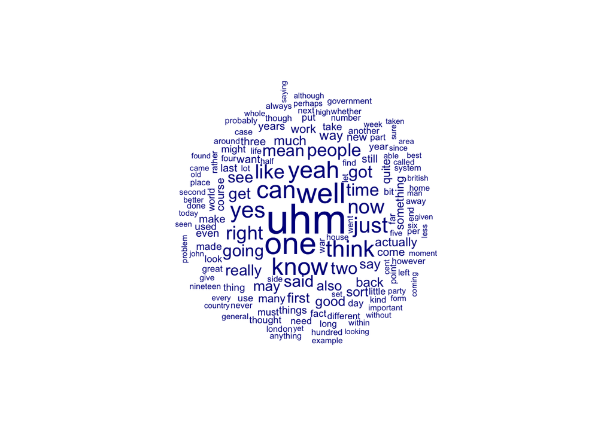

```r
dfmat_content <- dfm_remove(dfmat, pattern = stopwords("en"))
dfmat_content <- dfm_select(dfmat_content, min_nchar = 3)

textplot_wordcloud(dfmat_content, max_words = 150)
```

### Zipf’s law

Plotting token frequencies against frequency ranks yields the famous **Zipfian curve** – a small number of high-frequency types followed by a long tail of extremely rare ones:

**Detour: Zipf’s law**

George Kingsley Zipf (Zipf 1949) identified one of the most fundamental statistical regularities in linguistics. It becomes evident when frequency and frequency rank are examined side by side (see the plots below). Here, **frequency rank** refers to a word’s position in a frequency hierarchy: Rank 1 denotes the most frequent word, Rank 2 the second most frequent, and so on.

We denote the frequency of a word by $f$ and its frequency rank by $r$. Given a free parameter $\alpha$ and a normalising constant $C$, Zipf proposed the following power-law relationship:

$$f = \frac{C}{r^\alpha}$$

In concrete terms, the frequency of a word is inversely proportional to its frequency rank raised to the power of $\alpha$. For $\alpha = 1$, the second most frequent word occurs about half as often as the most frequent one, the third most frequent word about a third as often, and so on. In log-space, this relationship becomes linear (additive), with slope $-\alpha$:

$$\begin{aligned}
\log(f) &= \log \frac{C}{r^\alpha} \\
&= \log C - \alpha \log r.
\end{aligned}$$

For further details and extensions, see Baayen (2001).

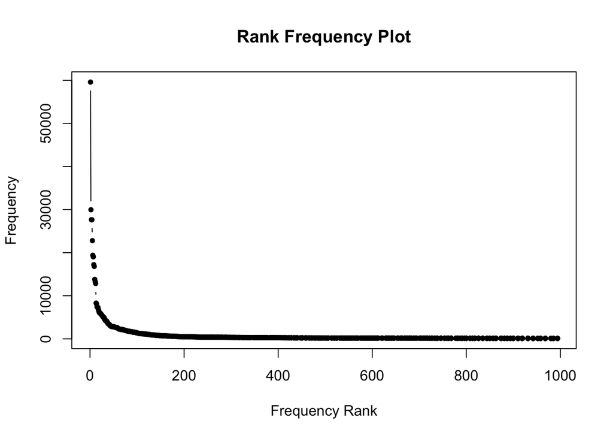

```r
# Check and plot distribution of the 1000 most frequent words in ICE-GB
freq <- textstat_frequency(dfmat, n = 1000)

plot(freq$rank, freq$frequency,
     type = "b", pch = 20,
     xlab = "Frequency Rank", ylab = "Frequency",
     main = "Rank Frequency Plot")
```

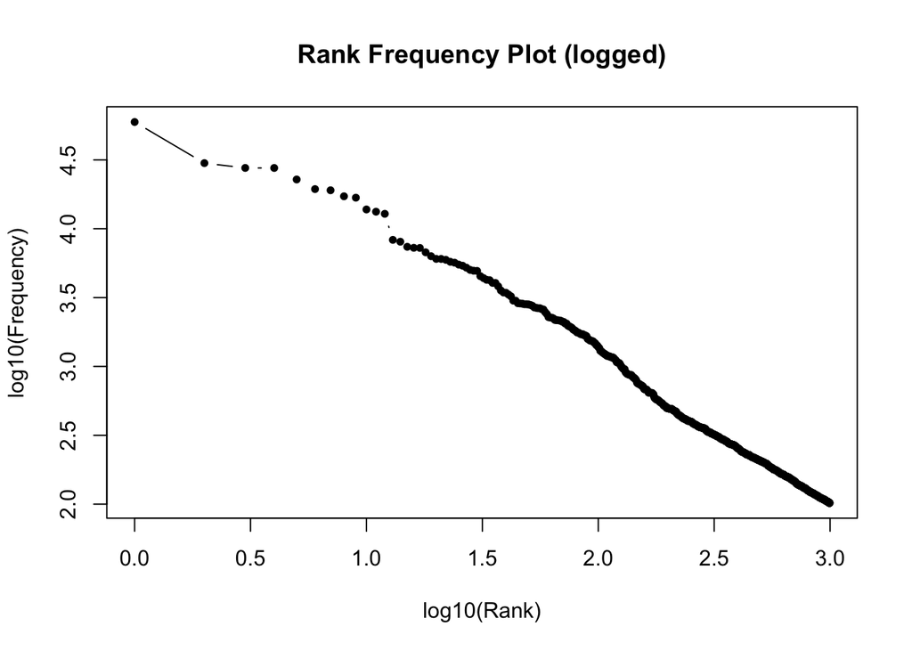

```r
# Log-scale
plot(log10(freq$rank), log10(freq$frequency),
     type = "b", pch = 20,
     xlab = "log10(Rank)", ylab = "log10(Frequency)",
     main = "Rank Frequency Plot (logged)")
```

### Lexical diversity

[figure not shown]

```r
ttr_stats <- textstat_lexdiv(ICE_GB_clean, measure = "TTR")

plot(ttr_stats$TTR,
     type = "l",
     main = "Type-Token Ratio across Documents",
     xlab = "Document Index",
     ylab = "Type-Token Ratio")
```

## Alternative concordancing software

There is a wide variety of concordancing software available, both free and paid. Among the most popular options are AntConc (Anthony 2020) and Sketch Engine (Kilgarriff et al. 2004). However, as Schweinberger (2024) notes, the exact processes these tools use to generate output are not always fully transparent, making them something of a ‘black box’. In contrast, programming languages like R or Python allow researchers to document each step of their analysis clearly, providing full transparency from start to finish.

## References

Anthony, Lawrence. 2020. *AntConc (Version 3.5.9)*. Tokyo, Japan: Waseda University. https://www.laurenceanthony.net/software.

Baayen, R. Harald. 2001. *Word Frequency Distributions*. Vol. 18. Dordrecht: Kluwer.

Benoit, Kenneth, Kohei Watanabe, Haiyan Wang, Paul Nulty, Adam Obeng, Stefan Müller, and Akitaka Matsuo. 2018. “Quanteda: An r Package for the Quantitative Analysis of Textual Data.” *Journal of Open Source Software* 3 (30): 774. https://doi.org/10.21105/joss.00774.

Kilgarriff, Adam, Pavel Rychly, Pavel Smrz, and David Tugwell. 2004. “ITRI-04-08 the Sketch Engine.” *Information Technology* 105: 116.

Lange, Claudia, and Sven Leuckert. 2020. *Corpus Linguistics for World Englishes: A Guide for Research*. New York: Taylor; Francis.

McEnery, Tony, Richard Xiao, and Tono Yukio. 2006. *Corpus-Based Language Studies: An Advanced Resource Book*. London: Routledge.

Schweinberger, Martin. 2024. *Concordancing with r*. 2024.05.07 ed. Brisbane: The Language Technology; Data Analysis Laboratory (LADAL). https://ladal.edu.au/kwics.html.

Wulff, Stefanie, and Paul Baker. 2020. “Analyzing Concordances.” In *A Practical Handbook of Corpus Linguistics*, edited by Magali Paquot and Stefan Th. Gries, 161–79. Cham: Springer International Publishing. https://doi.org/10.1007/978-3-030-46216-1_8.

Zipf, George Kingsley. 1949. *Human Behavior and the Principle of Least Effort*. Oxford, England: Addison-Wesley Press.